# Loading and preprocessing the data

## Loading and preprocessing the data

```r
unzip ("./activity.zip")
file <- read.csv("./activity.csv")
ds1 <- file %>% mutate(date = as.Date(date))
head(ds1)
```

```
##   steps       date interval
## 1    NA 2012-10-01        0
## 2    NA 2012-10-01        5
## 3    NA 2012-10-01       10
## 4    NA 2012-10-01       15
## 5    NA 2012-10-01       20
## 6    NA 2012-10-01       25
```

## What is mean total number of steps taken per day?

Histogram of the total number of steps taken each day.

```r
ds2 <- ds1 %>% group_by(date) %>% summarize(total = sum(steps))
ds2
```

```
## Source: local data frame [61 x 2]
##
##          date total
## 1  2012-10-01    NA
## 2  2012-10-02   126
## 3  2012-10-03 11352
## 4  2012-10-04 12116
## 5  2012-10-05 13294
## 6  2012-10-06 15420
## 7  2012-10-07 11015
## 8  2012-10-08    NA
## 9  2012-10-09 12811
## 10 2012-10-10  9900
## ..        ...   ...
```

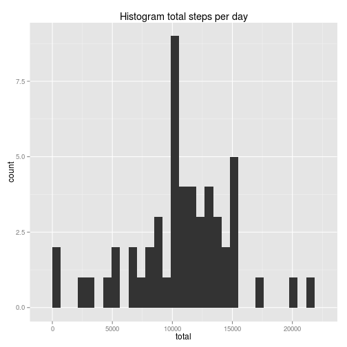

```r
qplot(total, data = ds2, main = "Histogram total steps per day")
```

Mean and median total number of steps taken per day.

```r
ds2 %>% summarize(avg = mean(total, na.rm = TRUE), med = median(total, na.rm = TRUE))
```

```
## Source: local data frame [1 x 2]
##
##        avg   med
## 1 10766.19 10765
```

## What is the average daily activity pattern?

Time series plot of the 5-minute interval (x-axis) and the average number of steps taken, averaged across all days (y-axis)

```r
ds4 <- ds1 %>% group_by(interval) %>% summarize(avg = mean(steps, na.rm = TRUE))
ds4
```

```
## Source: local data frame [288 x 2]
##
##    interval       avg
## 1         0 1.7169811
## 2         5 0.3396226
## 3        10 0.1320755
## 4        15 0.1509434
## 5        20 0.0754717
## 6        25 2.0943396
## 7        30 0.5283019
## 8        35 0.8679245
## 9        40 0.0000000
## 10       45 1.4716981
## ..      ...       ...
```

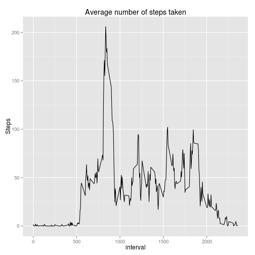

```r
qplot(interval, avg, data = ds4, geom = "line", ylab = "Steps",
      main = "Average number of steps taken")
```

5-minute interval, on average across all the days in the dataset, with the maximum number of steps.

```r
ds4 %>% filter(avg == max(ds4$avg))
```

```
## Source: local data frame [1 x 2]
##
##   interval      avg
## 1      835 206.1698
```

## Imputing missing values

Total number of missing values in the dataset.

```r
## Missing values in the dataset
sum(is.na(ds1$steps))
```

```
## [1] 2304
```

Missing values per day.

```r
ds1 %>% filter(is.na(steps)) %>% group_by(date) %>% summarize(n())
```

```
## Source: local data frame [8 x 2]
##
##         date n()
## 1 2012-10-01 288
## 2 2012-10-08 288
## 3 2012-11-01 288
## 4 2012-11-04 288
## 5 2012-11-09 288
## 6 2012-11-10 288
## 7 2012-11-14 288
## 8 2012-11-30 288
```

Select median for the 5-min interval to fill in values.

```r
## Median for each 5-min interval
ds5 <- ds1 %>% group_by(interval) %>% summarize(med = median(steps, na.rm = TRUE))
ds5
```

```
## Source: local data frame [288 x 2]
##
##    interval med
## 1         0   0
## 2         5   0
## 3        10   0
## 4        15   0
## 5        20   0
## 6        25   0
## 7        30   0
## 8        35   0
## 9        40   0
## 10       45   0
## ..      ... ...
```

Time series plot of median 5-min interval.

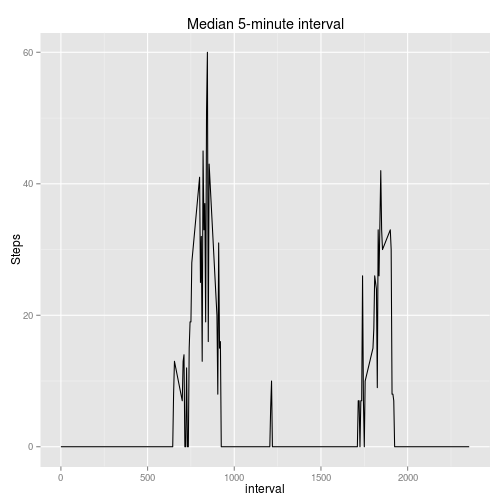

```r
## Time series plot
qplot(interval, med, data= ds5, geom = "line", ylab = "Steps",
      main = "Median 5-minute interval")
```

Filling in missing values with the median for the 5-min interval.

```r
## Missing values filling in
ds6 <- ds1 %>% group_by(interval) %>% mutate(med = median(steps, na.rm = TRUE)) %>%
    mutate(steps.med = ifelse(is.na(steps), med, steps)) %>%
    select(date, interval, steps.med)
ds6
```

```
## Source: local data frame [17,568 x 3]
## Groups: interval
##
##          date interval steps.med
## 1  2012-10-01        0         0
## 2  2012-10-01        5         0
## 3  2012-10-01       10         0
## 4  2012-10-01       15         0
## 5  2012-10-01       20         0
## 6  2012-10-01       25         0
## 7  2012-10-01       30         0
## 8  2012-10-01       35         0
## 9  2012-10-01       40         0
## 10 2012-10-01       45         0
## ..        ...      ...       ...
```

Histogram of the total number of steps taken each day.

```r
## Number of steps taken each day
ds8 <- ds6 %>% group_by(date) %>% summarize(total = sum(steps.med))
ds8
```

```
## Source: local data frame [61 x 2]
##
##          date total
## 1  2012-10-01  1141
## 2  2012-10-02   126
## 3  2012-10-03 11352
## 4  2012-10-04 12116
## 5  2012-10-05 13294
## 6  2012-10-06 15420
## 7  2012-10-07 11015
## 8  2012-10-08  1141
## 9  2012-10-09 12811
## 10 2012-10-10  9900
## ..        ...   ...
```

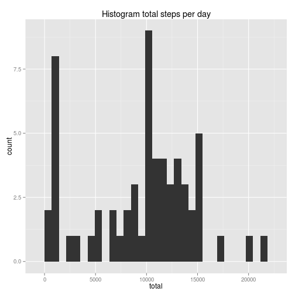

```r
qplot(total, data = ds8, main = "Histogram total steps per day")
```

Mean and median total number of steps taken per day.

```r
ds8 %>% summarize(avg = mean(total), med = median(total))
```

```
## Source: local data frame [1 x 2]
##
##        avg   med
## 1 9503.869 10395
```

## Are there differences in activity patterns between weekdays and weekends?

```r
## Set locale
Sys.setlocale("LC_TIME", locale = "en_US.UTF-8")
```

```
## [1] "en_US.UTF-8"
```

```r
## Weekdays
ds10 <- ds6 %>% mutate(weekday = weekdays(date))

## Weekdays as weekend, weekday
ds11 <- ds10 %>% mutate(wd = as.factor(
    ifelse(weekday %in% c("Saturday", "Sunday"), "weekend", "weekday")))
head(ds11)
```

```
## Source: local data frame [6 x 5]
## Groups: interval
##
##         date interval steps.med weekday      wd
## 1 2012-10-01        0         0  Monday weekday
## 2 2012-10-01        5         0  Monday weekday
## 3 2012-10-01       10         0  Monday weekday
## 4 2012-10-01       15         0  Monday weekday
## 5 2012-10-01       20         0  Monday weekday
## 6 2012-10-01       25         0  Monday weekday
```

Time series plot of the 5-minute interval (x-axis) and the average number of steps taken, averaged across all weekday days or weekend days.

```r
## Averaged across all weekday days or weekend
ds12 <- ds11 %>% group_by(interval, wd) %>% summarize(avg = mean(steps.med))
head(ds12)
```

```
## Source: local data frame [6 x 3]
## Groups: interval
##
##   interval      wd       avg
## 1        0 weekday 2.0222222
## 2        0 weekend 0.0000000
## 3        5 weekday 0.4000000
## 4        5 weekend 0.0000000
## 5       10 weekday 0.1555556
## 6       10 weekend 0.0000000
```

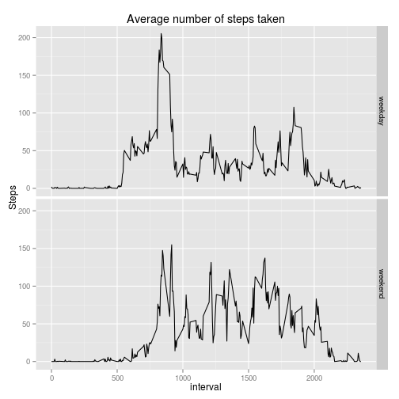

```r
qplot(interval, avg, data = ds12, facets = wd ~ ., geom = "line", ylab = "Steps",
      main = "Average number of steps taken")
```